# a3_task3_Craig_Stuart

Craig Stuart

11/1/2020

```r
knitr::opts_chunk$set(echo = TRUE)
# Load necessary packages
library(tidyverse)
library(here)
library(janitor)
library(knitr)
library(lubridate)
```

## Task 3 Objective:

- Use version control, project management, and data wrangling, analysis and visualization skills to explore red and purple urchin samples recorded by Santa Barbara Coastal Long Term Ecological Research program divers. This task will be broken up into multiple sections in which I will compare the distribution of red and purple urchin sizes and then explore the number of urchins samples by site and year.

#### Read in urchins.csv data

```r
sb_urchins <- read_csv(here("data", "urchins.csv"))
```

#### Clean variable names in data

```r
sb_clean_urchins <- sb_urchins %>%
  clean_names()
```

## Section 1: Size comparisons of purple and red urchins

### 1. Compare the distribution of purple and red urchin sizes

- use `ggplot()` and `geom_histogram` to Visualize the size distribution between purple and red urchins.

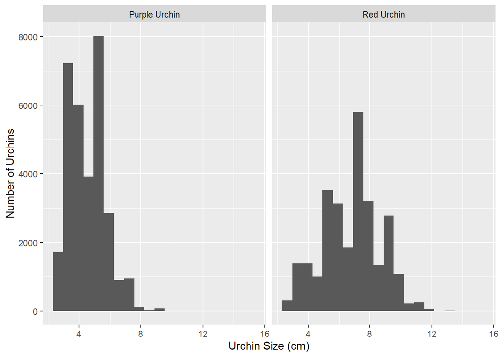

```r
ggplot(data = sb_clean_urchins, aes(x = size)) +
  geom_histogram(bins = 20) +
  facet_wrap(~common_name) +
  labs(x = "Urchin Size (cm)", y = "Number of Urchins")
```

- use `ggplot()` and `geom_boxplot` to Visualize the size distribution between purple and red urchins in an alternate way.

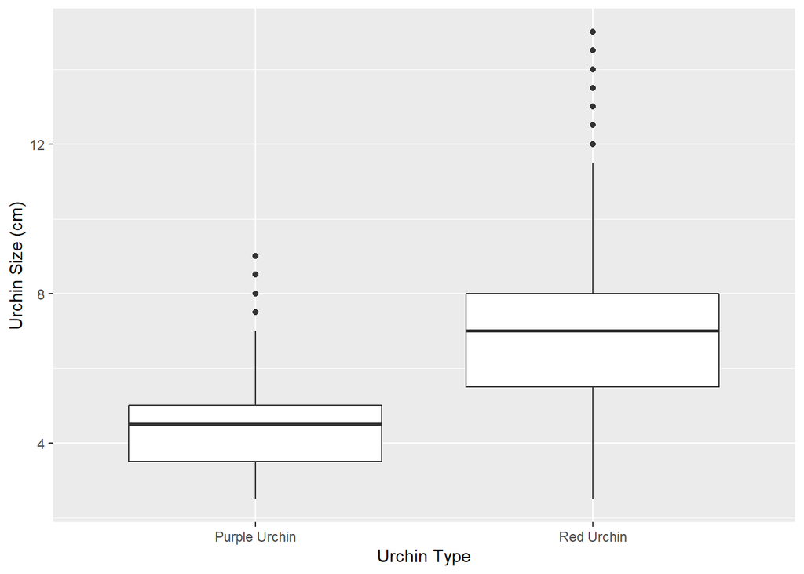

```r
ggplot(data = sb_clean_urchins,
       aes(x = common_name, y = size)) +
  geom_boxplot() +
  labs(x = "Urchin Type", y = "Urchin Size (cm)")
```

### 2. Create a summary statistics table

- Group urchin color by `common_name` and summarize the mean, median, sd, and sample size(n)

```r
urchin_stats <- sb_clean_urchins %>%
  group_by(common_name) %>%
  summarise(mean_urchin = mean(size),
            med_urchin = median(size),
            sd_urchin = sd(size),
            n = n())
kable(urchin_stats)
```

| common_name | mean_urchin | med_urchin | sd_urchin | n |
| --- | --- | --- | --- | --- |
| Purple Urchin | 4.469797 | 4.5 | 1.175264 | 31805 |
| Red Urchin | 6.776489 | 7.0 | 1.891343 | 27408 |

```r
# Actual difference between urchin population means
6.776489 - 4.469797
```

```
## [1] 2.306692
```

```r
# Percent Difference between urchin population means
(6.776489 - 4.469797) / ((6.776489 + 4.469797)/2) * 100
```

```
## [1] 41.0214
```

## Section 2: Explore Purple Urchin Counts by Site and Year

### 1. Wrangle data to create a subset of purple urchin data

- Filter purple urchins
- Convert date to class
- Create a new column of year and site name

```r
purple_urchin <- sb_clean_urchins %>%
  filter(common_name == "Purple Urchin") %>%
  mutate(date_new = mdy(date)) %>%
  mutate(year_new = year(date_new)) %>%
  mutate(site_full = case_when(
    site %in% "NAPL" ~ "Naples Reef",
    site %in% "AQUE" ~ "Arroyo Quemado Reef",
    site %in% "CARP" ~ "Carpinteria Reef",
    site %in% "MOHK" ~ "Mohawk Reef",
    site %in% "IVEE" ~ "Isla Vista Reef"
  ))

class(purple_urchin)
```

```
## [1] "spec_tbl_df" "tbl_df"      "tbl"         "data.frame"
```

### 2. Make a summary table containing the total number of purple urchins observed by site and year

- Summarize the number of purple urchins per site, per year
- Use the `group_by()` and `count()` functions to orgnaize summary table

```r
purple_urchin_stats <- purple_urchin %>%
  group_by(year_new) %>%
  count(site_full, year_new)

kable(purple_urchin_stats)
```

| year_new | site_full | n |
| --- | --- | --- |
| 2008 | Arroyo Quemado Reef | 67 |
| 2008 | Carpinteria Reef | 265 |
| 2008 | Mohawk Reef | 294 |
| 2008 | Naples Reef | 246 |
| 2009 | Arroyo Quemado Reef | 926 |
| 2009 | Carpinteria Reef | 1315 |
| 2009 | Mohawk Reef | 1344 |
| 2009 | Naples Reef | 1064 |
| 2010 | Arroyo Quemado Reef | 921 |
| 2010 | Carpinteria Reef | 930 |
| 2010 | Mohawk Reef | 923 |
| 2010 | Naples Reef | 942 |
| 2011 | Arroyo Quemado Reef | 887 |
| 2011 | Carpinteria Reef | 1118 |
| 2011 | Mohawk Reef | 958 |
| 2011 | Naples Reef | 883 |
| 2012 | Arroyo Quemado Reef | 764 |
| 2012 | Carpinteria Reef | 743 |
| 2012 | Isla Vista Reef | 797 |
| 2012 | Mohawk Reef | 856 |
| 2012 | Naples Reef | 738 |
| 2013 | Arroyo Quemado Reef | 434 |
| 2013 | Carpinteria Reef | 400 |
| 2013 | Isla Vista Reef | 370 |
| 2013 | Mohawk Reef | 399 |
| 2013 | Naples Reef | 357 |
| 2014 | Arroyo Quemado Reef | 410 |
| 2014 | Carpinteria Reef | 415 |
| 2014 | Isla Vista Reef | 436 |
| 2014 | Mohawk Reef | 440 |
| 2014 | Naples Reef | 368 |
| 2015 | Arroyo Quemado Reef | 400 |
| 2015 | Carpinteria Reef | 430 |
| 2015 | Isla Vista Reef | 402 |
| 2015 | Mohawk Reef | 418 |
| 2015 | Naples Reef | 430 |
| 2016 | Arroyo Quemado Reef | 342 |
| 2016 | Carpinteria Reef | 423 |
| 2016 | Isla Vista Reef | 372 |
| 2016 | Mohawk Reef | 402 |
| 2016 | Naples Reef | 384 |
| 2017 | Arroyo Quemado Reef | 406 |
| 2017 | Carpinteria Reef | 404 |
| 2017 | Isla Vista Reef | 362 |
| 2017 | Mohawk Reef | 434 |
| 2017 | Naples Reef | 393 |
| 2018 | Arroyo Quemado Reef | 408 |
| 2018 | Carpinteria Reef | 474 |
| 2018 | Isla Vista Reef | 416 |
| 2018 | Mohawk Reef | 459 |
| 2018 | Naples Reef | 462 |
| 2019 | Arroyo Quemado Reef | 404 |
| 2019 | Carpinteria Reef | 466 |
| 2019 | Isla Vista Reef | 299 |
| 2019 | Mohawk Reef | 369 |
| 2019 | Naples Reef | 474 |
| 2020 | Arroyo Quemado Reef | 98 |
| 2020 | Carpinteria Reef | 130 |
| 2020 | Isla Vista Reef | 100 |
| 2020 | Mohawk Reef | 134 |
| 2020 | Naples Reef | 100 |

- Make exploratory graph to visualize counts of purple urchins at each site

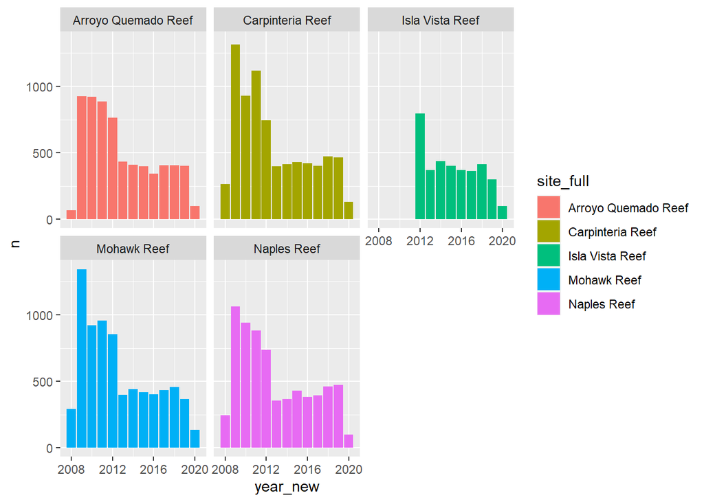

```r
ggplot(data = purple_urchin_stats, aes(x = year_new, y = n, fill = site_full)) +
  geom_col() +
  facet_wrap(~site_full)
```